# R Notebook

# Data

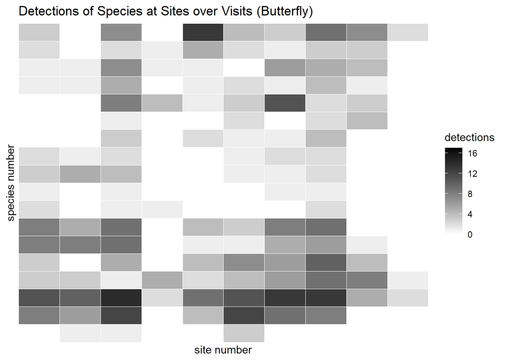

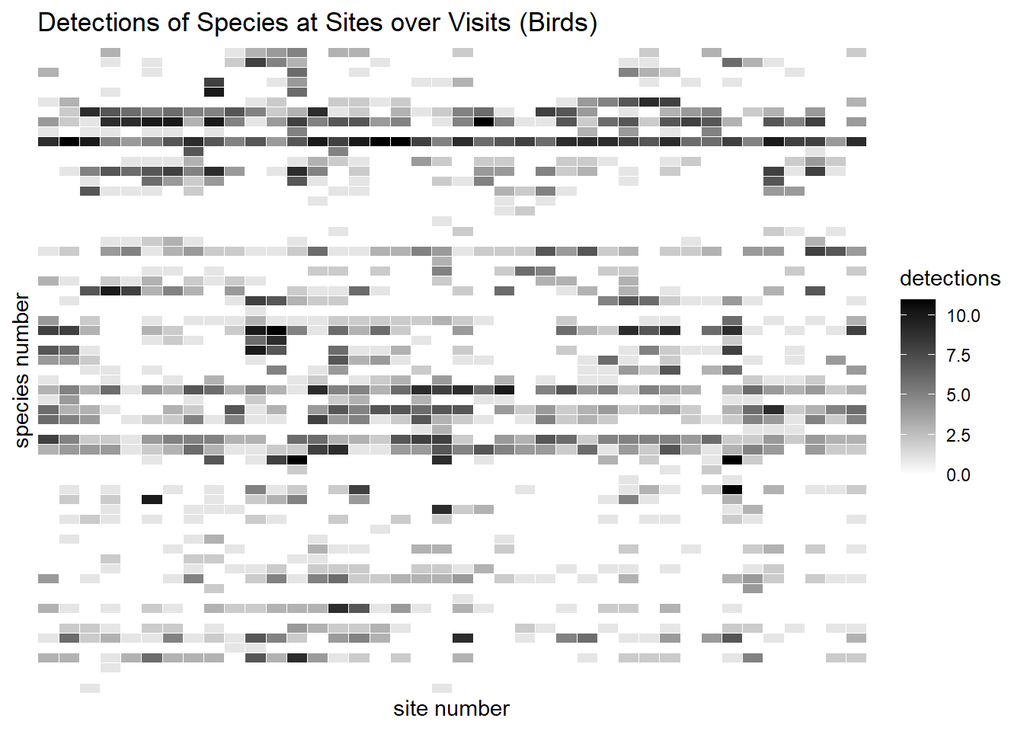

# Model

## Problem formulation

Suppose we have $S$ species in total that are potentially present in this area. Let $w_i=1$ denote that species $i$ is present, and $w_i=0$ is not. We are interested in $P(\sum_{i=1}^S w_i\mid Data)$

Obviously, if a species is detected at least once, then $w_i=1$; but if a species is not detected, it is uncertain if it’s because the species is not in the community or it is there but just not detected.

**Question:** How $w_i$ is related to the likelihood?

Thought: it is a long chain

$w_i$ determines whether a species will have no chance of being present in any sites.

- If $w_i=0$, then this species will have no chance of being present in any sites.
- If $w_i=1$, this species might be present (or not) in some sites

Let $i$ denote species, $j$ denote site, $z_{ij}=1$ denote species $i$ is present at site $j$. We have:

$$z_{ij} \sim Bernoulli(w_i\psi_{ij})$$
If the species is present at a specific site ($Z_{ij}=1$), then the detection time follows $Binomial(K, \theta)$, K is the total number of visit time for that site. If not, the detection time will be 0.

Let $x_{ij}$ be the number of detection times for species $i$ at site $j$, it follows:

$$x_{ij} \sim Binomial(K, z_{ij}\theta_{ij})$$

With this model, for those undetected species, we can calculate the probability:

1. $w_i=0$(it is not in the community)
2. $w_i=1, z_{ij}=0, j=1,...,J$ (it is in the community but not in the sampled sites)
3. $w_i=1$, $z_{ij} \neq 0$ for some $j$, and $x_{ij}=0$ for $j=1,\ldots,J$. (it is in some sites but not detected)

## Model simplification

Let $\psi_{ij}=\psi_i$ (some occurrence probability across sites), $\theta_{ij}=\theta_i$ (some detection probability across sites)

## Create hierarchical structure

$$\left(logit(\psi_i),logit(\theta_i)\right)\sim
MVN([\alpha,\beta]^T, \Sigma)$$

For the undetected species, it is impossible to estimate $\psi_i$ and $\theta_i$ without borrowing information from other species.

$$w_i\sim Bernoulli(\Omega)$$

## Other priors

weakly informative